# My_SpotifyR_Report

Author

David Fančovič

## Who is ROSALÍA? - Quick Facts!

- **2-time Grammy Award** and **12-time Latin Grammy Award winning** artist and producer
- breakout album **“El Mal Querer”** meshed an innovative **fusion of Flamenco** and other **timeless music styles of Spain**
- historic first-ever **Best New Artist Grammy nomination** for a Spanish language artist
- global press dubbing **MOTOMAMI**: *“a visionary masterpiece… as provocative and risky as it is creative… the most thrilling, forward-thinking music we’ll hear all year…[and] one of the most ambitious albums of the decade — regardless of genre”*.
- **MOTOMAMI** debuted at **#1 on Spotify’s Global Album Chart,** (a first-ever accomplishment for a Spanish artist),
- **the strongest Billboard chart debut of any 2022 Latin album**
- **highest Metacritic rating (95)** of any album released that year.

info from official website: https://www.rosalia.com/

### Album Covers (aka Art Museum Entries)

[figure not shown]

[figure not shown]

[figure not shown]

### Favourite Album - MOTOMAMIIIIIIII

[figure not shown]

### ❤️My favourite song❤️

[ROSALÍA - SAOKO (Official Video)](https://www.youtube.com/watch?v=6o7bCAZSxsg)

#### 🎶My favourite lyrics! 🎶

*“Me contradigo, yo me transformo*

*Soy to’a’ la’ cosa’, yo me transformo”*

- SAOKO

(I contradict myself, I transform, I’m everything, I transform)

## Deep dive into ROSALÍA’s song statistics

```r
library(ggplot2)
library(dplyr)
library(knitr)
ROSALÍA <- read.csv("ROSALÍA.csv")
```

### A quick look at ROSALÍA’s songs:

```r
ROSALÍA |>  dplyr:: slice_sample(n=5)|> knitr::kable(digits=2)
```

| artist_name | track_name | track_number | album_name | album_release_year | album_release_date | valence | energy | danceability | loudness | tempo | speechiness | instrumentalness | liveness | key_name | mode_name | key_mode | duration_ms |
| --- | --- | --- | --- | --- | --- | --- | --- | --- | --- | --- | --- | --- | --- | --- | --- | --- | --- |
| ROSALÍA | MALAMENTE - Cap.1: Augurio | 1 | El Mal Querer | 2018 | 2018-11-02 | 0.53 | 0.48 | 0.89 | -4.78 | 97.97 | 0.09 | 0.02 | 0.08 | C | minor | C minor | 150027 |
| ROSALÍA | BAGDAD - Cap.7: Liturgia | 7 | El Mal Querer | 2018 | 2018-11-02 | 0.36 | 0.36 | 0.71 | -8.89 | 80.06 | 0.05 | 0.00 | 0.10 | C | minor | C minor | 182657 |
| ROSALÍA | A NINGÚN HOMBRE - Cap.11: Poder | 11 | El Mal Querer | 2018 | 2018-11-02 | 0.41 | 0.15 | 0.56 | -6.60 | 107.78 | 0.04 | 0.00 | 0.14 | C | major | C major | 94223 |
| ROSALÍA | DI MI NOMBRE - Cap.8: Éxtasis | 8 | El Mal Querer | 2018 | 2018-11-02 | 0.55 | 0.53 | 0.79 | -6.47 | 91.87 | 0.13 | 0.00 | 0.31 | G# | minor | G# minor | 162376 |
| ROSALÍA | CUUUUuuuuuute | 12 | MOTOMAMI + | 2022 | 2022-09-09 | 0.16 | 0.49 | 0.62 | -8.99 | 139.89 | 0.36 | 0.00 | 0.17 | C# | major | C# major | 150701 |

### Data preparation

```r
#removing records with the same track names
ROSALÍA <- ROSALÍA |> distinct(track_name, .keep_all = TRUE)
#filter out track names that include "live at"
ROSALÍA <- ROSALÍA |> filter(!grepl("Live At|Live Acoustic","Live en el Palau Sant Jordi",track_name))
```

### Graphs.

ROSALÍA throughout years expanded the scope of her music. Her first album *Los Ángeles* appears to me as the most traditional, using many flamenco elements. Her second album is still true to these elements but adds new modern twists. Finally, *MOTOMAMI* represents a change from traditional to more experimental music, since it was meant to be a concept album.

Due to these changes in style, I would first like to look at different danceability of ROSALÍA’s albums.

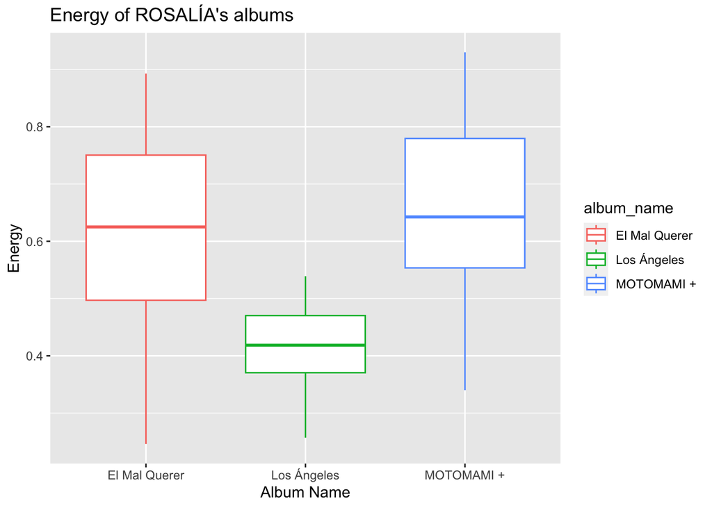

```r
#changing album name from characters to factors
ROSALÍA$album_name <- as.factor(ROSALÍA$album_name)
#plotting a boxplot
ggplot(ROSALÍA, aes(x=album_name, y=danceability, color=album_name))+
  geom_boxplot()+
  labs(title= "Energy of ROSALÍA's albums", x="Album Name", y="Energy")
```

These results do not surprise me. Based on her live perfomances of *Los Ángeles* songs, she is not dancing much, yet her music is very expressive in tone and emotion.

(You can watch her live performance of Los Ángeles album here! https://www.youtube.com/watch?v=varnR9n_wfc)

*El Mal Querer* and *MOTOMAMI* are certainly much more danceable albums.

ROSALÍA’s last album (MOTOMAMI) had much more aggressive elements, such as distorted drums, autotune, jazz-features and drawn to a great extent from the **reggaeton music,** which to me seems a bit more fast-paced than flamenco used in *El Mal Querer.*

That’s why I would like to compare the **tempo** levels of the *El Mal Querer* and *MOTOMAMI+* albums.

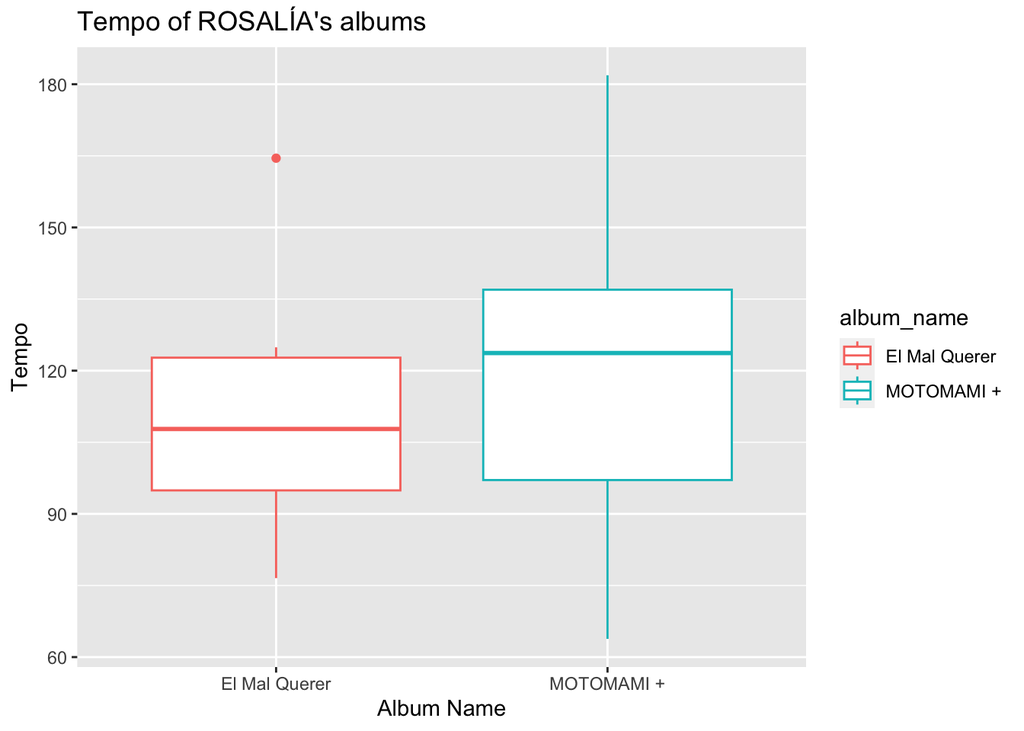

```r
ROSALÍA$album_name <- as.factor(ROSALÍA$album_name)
#I want to select only El Mal Querer and MOTOMAMI + albums
selected_albums <- c("El Mal Querer", "MOTOMAMI +")
El_MOTOMAMI <- ROSALÍA[ROSALÍA$album_name %in% selected_albums,]

#plotting a boxplot
ggplot(El_MOTOMAMI, aes(x=album_name, y=tempo, color=album_name))+
  geom_boxplot()+
  labs(title= "Tempo of ROSALÍA's albums", x="Album Name", y="Tempo")
```

It is visible that *MOTOMAMI* is much “faster” album on average in comparison to *El Mal Querer.*

*MOTOMAMI* boxplot has also a larger IQR, indicating greater spread and variety among songs when it comes to tempo.

It is indeed very experimental album, and that’s why I would be interested to see what is variance between individual songs on this album in terms of **valence** and **energy**. (my favourite song is indicated on the graph too!)

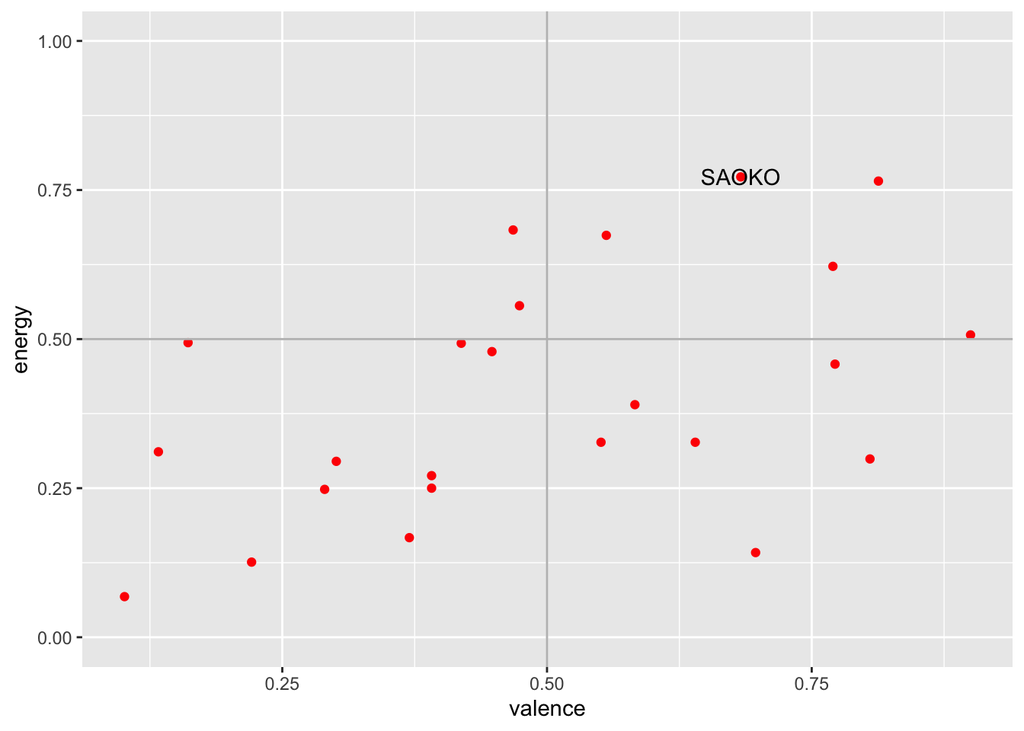

```r
#I want to select only MOTOMAMI + album
selected_album_1 <- c("MOTOMAMI +")
MOTOMAMI_album <- ROSALÍA[ROSALÍA$album_name %in% selected_album_1,]
subgroup <- c("SAOKO")
SAOKO_track <- ROSALÍA[ROSALÍA$track_name %in% subgroup,]

ggplot(MOTOMAMI_album, aes(x = valence, y = energy))+
  geom_point(color = "red")+
  geom_hline(yintercept = 0.5, color= "grey")+
  geom_vline(xintercept = 0.5, color="grey")+
  coord_cartesian(ylim = c(0, 1))+
  geom_text(data=SAOKO_track, aes(label=track_name))
```

```r
  labs(title= "Relationship between Valence and Energy of songs on MOTOMAMI+ album", x="Valence", y="Energy")
```

```
$x
[1] "Valence"

$y
[1] "Energy"

$title
[1] "Relationship between Valence and Energy of songs on MOTOMAMI+ album"

attr(,"class")
[1] "labels"
```

I wanted to see three songs that have the lowest valence and energy from the album.

```r
MOTOMAMI_album |> slice_min(valence, n=3)|> slice_min(energy, n=3)|>dplyr:: select(track_name, valence, energy)|> knitr::kable(digits=2)
```

| track_name | valence | energy |
| --- | --- | --- |
| G3 N15 | 0.10 | 0.07 |
| SAKURA | 0.13 | 0.31 |
| CUUUUuuuuuute | 0.16 | 0.49 |

Interesting! The first two did not personally surprise me but the third song does not sound very sad for me.

But anyways! Now I would like to zoom out and look how ROSALÍA’s **energy levels** has changed throughout the time with her albums:

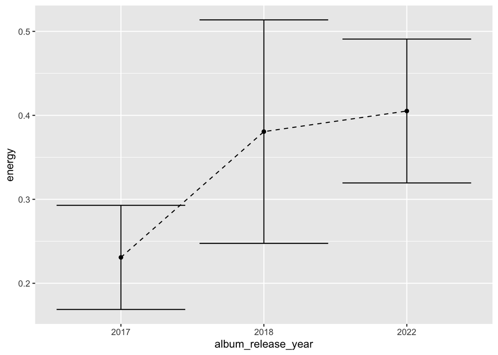

```r
ROSALÍA$album_release_year <- as.factor(ROSALÍA$album_release_year)

ggplot(ROSALÍA, aes(x = album_release_year, y = energy))+
  stat_summary(fun.y = mean, geom = "point")+
  stat_summary(fun.data = mean_cl_normal, geom = "errorbar")+
  stat_summary(fun.y = mean,aes(group=1), geom = "line", linetype = "dashed")
```

It seems that her energy levels were rising, most steeply between her first and second album, but also a bit between second and third!

Does this have any effect on **duration** of the tracks? Maybe she has more energy because he tracks are shorter and she does not get tired as quickly? Let’s see:

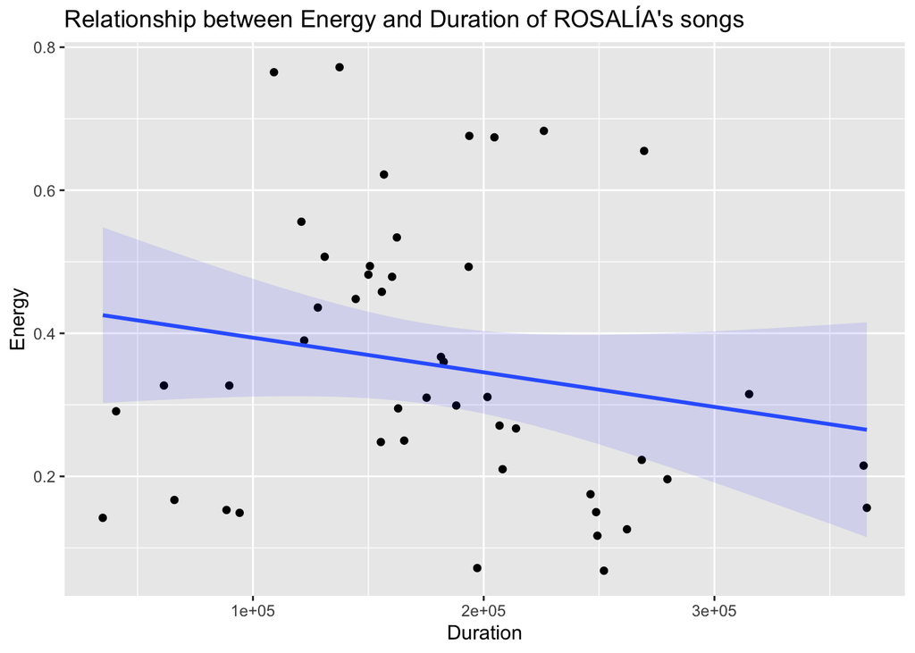

```r
ggplot(ROSALÍA, aes(x = duration_ms, y = energy,))+
   geom_point()+
   geom_smooth(method= "lm", alpha = 0.1, fill= "blue")+
   labs(title= "Relationship between Energy and Duration of ROSALÍA's songs", x="Duration", y="Energy")
```

Or maybe she used to sing much more during her earlier tracks and got tired more quickly? Let’s check how the **speechines** of her songs changed:

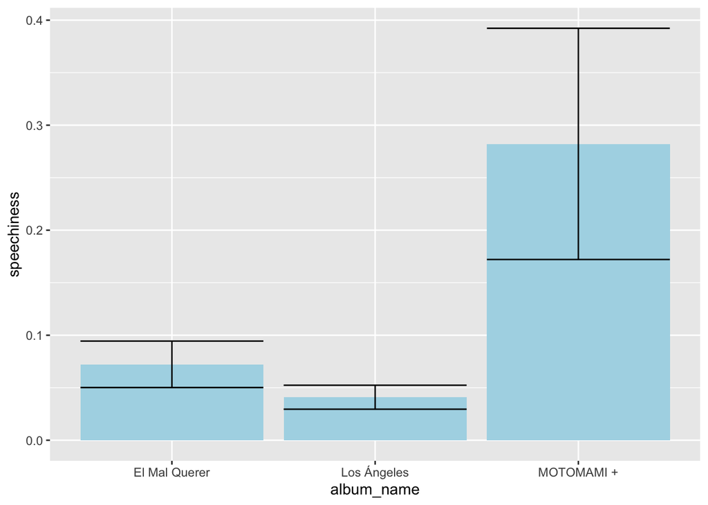

```r
ggplot(ROSALÍA, aes(x = album_name, y = speechiness))+
         stat_summary(fun.y = mean, geom = "bar", fill = "lightblue") +
         stat_summary(fun.data = mean_cl_normal, geom = "errorbar")
```

This shows that the MOTOMAMI is the album in which she sings the most!

### Bottom Line

Based on her interview for Billboard, ROSALÍA wanted her album to have *“roller coaster energy that is high and low, high and low.”* (full interview here: https://www.billboard.com/music/latin/rosalia-motomami-interview-1235047442/)

I think she did a great job with that, and these statistics show that!